# Seminaroppgave 3

Author

Theodor Bredal-Thorsen

```r
library(tidyverse)
library(rosdata)
library(rstanarm)
library(conflicted)
library(ggplot2)
library(tinytable)
library(broom)
library(broom.mixed)
library(knitr)
library(modelsummary)
conflicts_prefer(dplyr::filter,
                 dplyr::select,
                 quanteda::stopwords,
                 rosdata::data)
```

```r
dem_data <- read.csv("lijphart.csv")
```

# 1 Oppgave 1

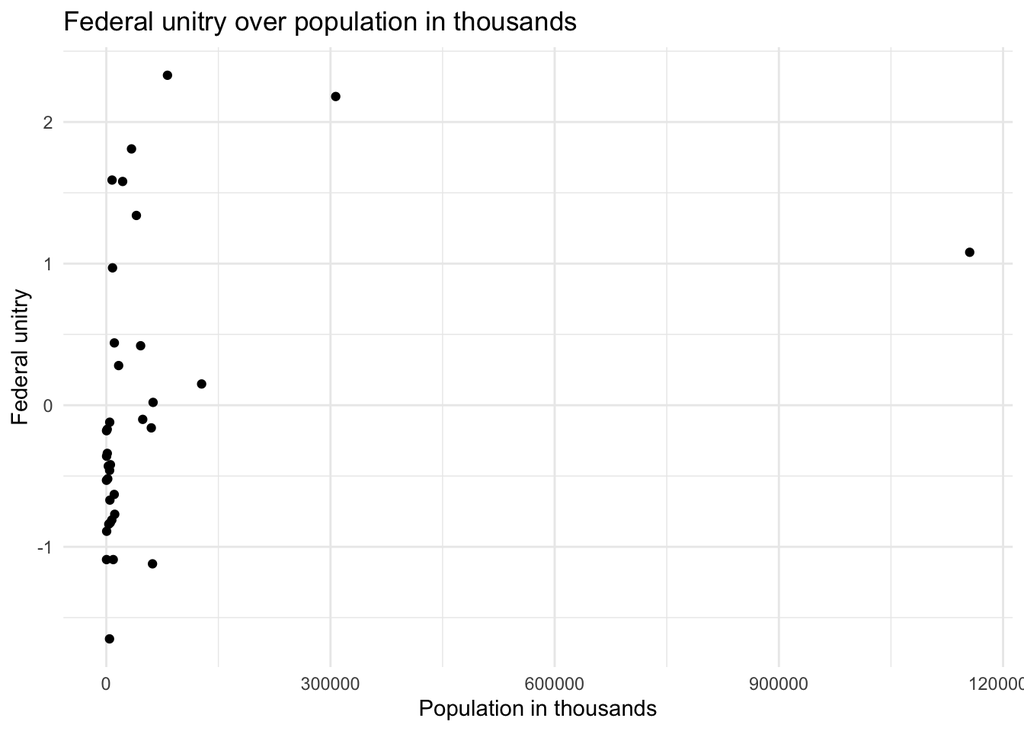

```r
scatter <- ggplot(data = dem_data, aes(x= pop_in_thousands_2009,y = federal_unitry_1981_2010)) +
  geom_point()+
  theme_minimal() +
  labs(
    title = "Federal unitry over population in thousands",
    x = "Population in thousands",
    y = "Federal unitry"
  )

scatter
```

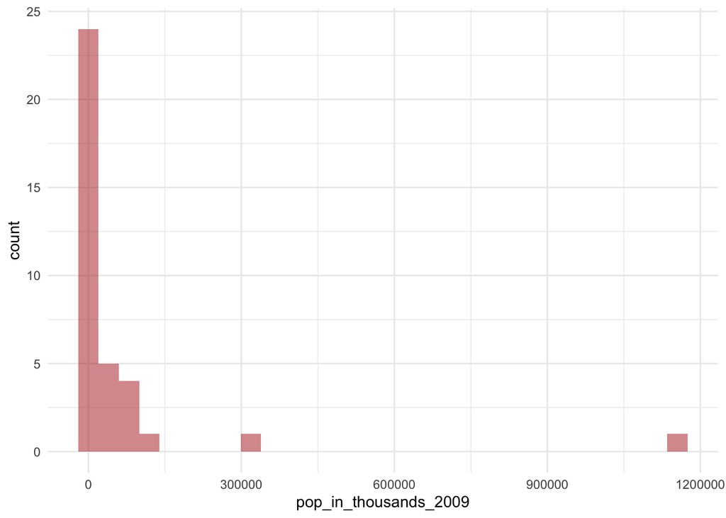

```r
histo <- ggplot(data = dem_data, aes(x = pop_in_thousands_2009)) +
  geom_histogram( fill = "firebrick", alpha = 0.5) +
  theme_minimal()

histo
```

Bekrefter høyreforskyvningen i populasjonsvariabelen!

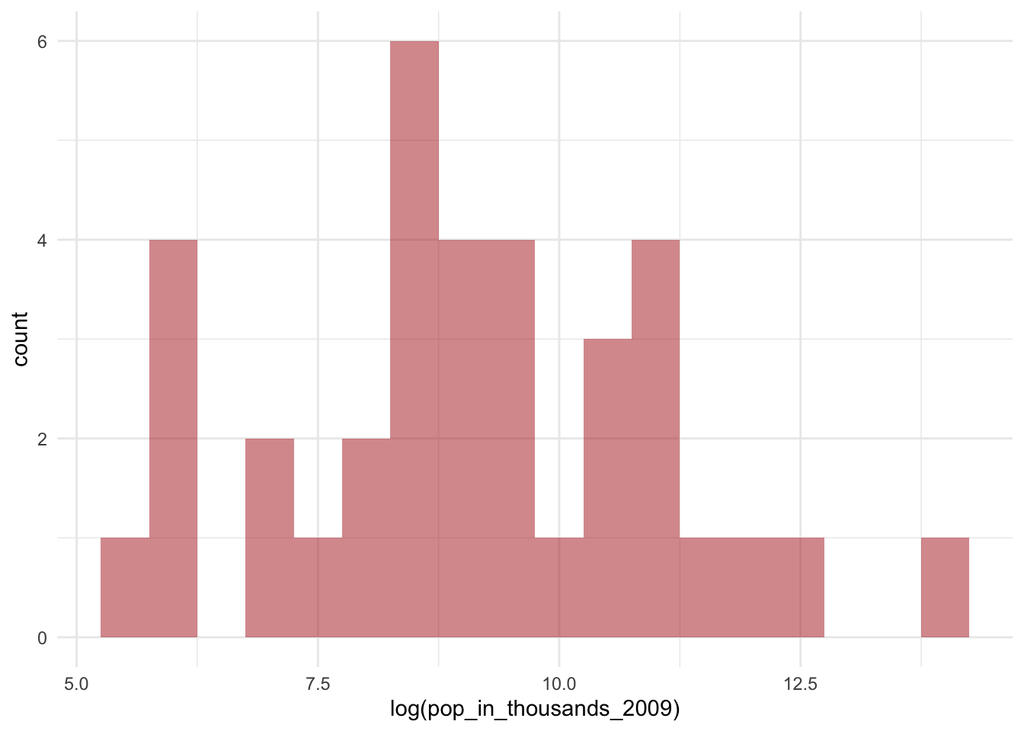

```r
histo_log <- ggplot(data = dem_data, aes(x = log(pop_in_thousands_2009))) +
  geom_histogram(binwidth = 0.5,
                 fill = "firebrick",
                 alpha = 0.5) +
  theme_minimal()

histo_log
```

Dette ser mer normalfordelt ut, den transformerte variabelen vil passe bedre til å modellere forholdet mellom befolkning og grad av føderalisme.

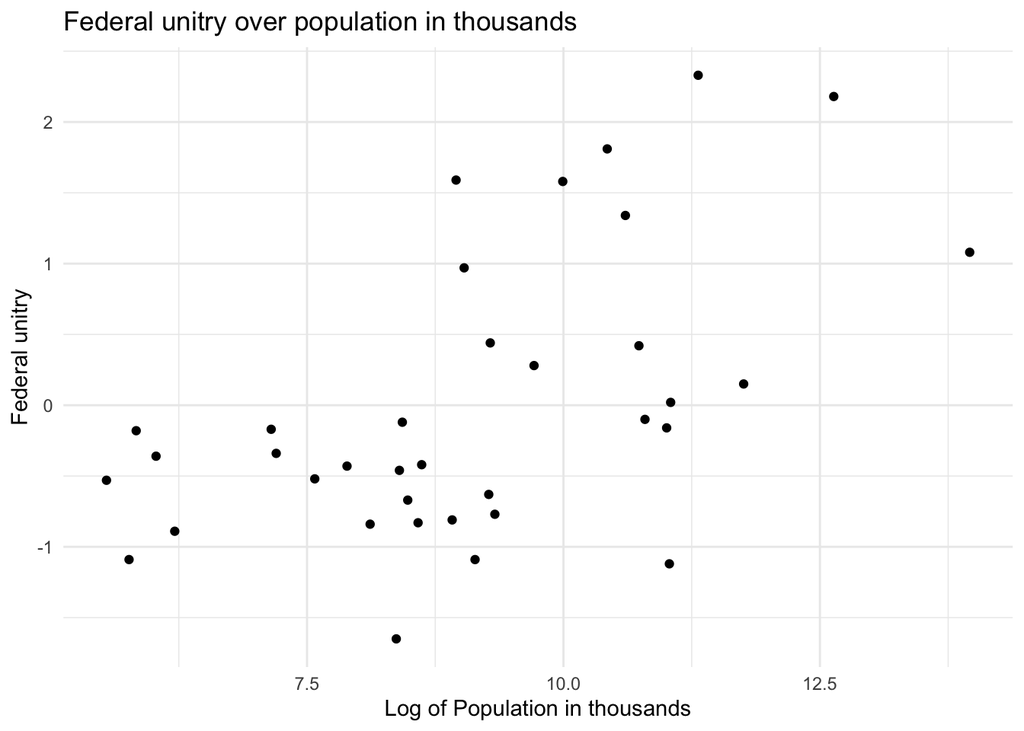

```r
scatter_log <- ggplot(data=dem_data, aes(x=log(pop_in_thousands_2009), y = federal_unitry_1981_2010)) +
  geom_point() +
  theme_minimal() +
   labs(
    title = "Federal unitry over population in thousands",
    x = "Log of Population in thousands",
    y = "Federal unitry"
  )

scatter_log
```

Variasjonen til føderasjon over den logaritmisk transformerte populasjonsvariabelen ser ut til å ha et mer lineært forhold.

# 2 Oppgave 2

```r
mod1 <- stan_glm(data = dem_data, federal_unitry_1981_2010 ~ log(pop_in_thousands_2009), refresh = 0)

modelsummary(mod1, output = "html")
```

|  | (1) |
| --- | --- |
| (Intercept) | −2.503 |
| log(pop_in_thousands_2009) | 0.276 |
| Num.Obs. | 36 |
| R2 | 0.288 |
| R2 Adj. | 0.245 |
| Log.Lik. | −44.919 |
| ELPD | −47.1 |
| ELPD s.e. | 3.9 |
| LOOIC | 94.2 |
| LOOIC s.e. | 7.7 |
| WAIC | 94.1 |
| RMSE | 0.83 |

```r
mod2 <- stan_glm(data = dem_data, federal_unitry_1981_2010 ~ plural_society_code, refresh = 0)

modelsummary(mod2, output = "html")
```

|  | (1) |
| --- | --- |
| (Intercept) | −0.264 |
| plural_society_code | 0.399 |
| Num.Obs. | 36 |
| R2 | 0.103 |
| R2 Adj. | 0.030 |
| Log.Lik. | −49.294 |
| ELPD | −51.9 |
| ELPD s.e. | 5.2 |
| LOOIC | 103.7 |
| LOOIC s.e. | 10.4 |
| WAIC | 103.7 |
| RMSE | 0.93 |

```r
mod3 <- stan_glm(data = dem_data,
                 federal_unitry_1981_2010 ~ log(pop_in_thousands_2009) + plural_society_code,
                 refresh= 0)
modelsummary(mod3, output = "html")
```

|  | (1) |
| --- | --- |
| (Intercept) | −2.437 |
| log(pop_in_thousands_2009) | 0.251 |
| plural_society_code | 0.252 |
| Num.Obs. | 36 |
| R2 | 0.333 |
| R2 Adj. | 0.226 |
| Log.Lik. | −44.159 |
| ELPD | −47.4 |
| ELPD s.e. | 4.1 |
| LOOIC | 94.9 |
| LOOIC s.e. | 8.1 |
| WAIC | 94.7 |
| RMSE | 0.80 |

```r
mod4 <- stan_glm(data = dem_data,
                 federal_unitry_1981_2010 ~ log(pop_in_thousands_2009) * plural_society_code,
                 refresh= 0)

modelsummary(mod4, output = "html")
```

|  | (1) |
| --- | --- |
| (Intercept) | −2.395 |
| log(pop_in_thousands_2009) | 0.245 |
| plural_society_code | 0.196 |
| log(pop_in_thousands_2009) × plural_society_code | 0.005 |
| Num.Obs. | 36 |
| R2 | 0.338 |
| R2 Adj. | 0.180 |
| Log.Lik. | −44.379 |
| ELPD | −48.5 |
| ELPD s.e. | 4.2 |
| LOOIC | 97.1 |
| LOOIC s.e. | 8.3 |
| WAIC | 96.7 |
| RMSE | 0.80 |

# 3 Oppgave 3

```r
modelsummary(list(mod1, mod2, mod3, mod4),
             output = "html",
             fmt = 2,
             statistic = "conf.int",
              coef_rename = c(
                "(Intercept)" = "Konstantledd",
                "log(pop_in_thousands_2009)" = "log(Populasjon)",
                "plural_society_code" = "Grad av pluralisme"
              ))
```

|  | (1) | (2) | (3) | (4) |
| --- | --- | --- | --- | --- |
| Konstantledd | −2.50 | −0.26 | −2.44 | −2.40 |
|  | [−3.85, −1.17] | [−0.68, 0.15] | [−3.79, −1.04] | [−4.14, −0.66] |
| log(Populasjon) | 0.28 |  | 0.25 | 0.24 |
|  | [0.13, 0.42] |  | [0.09, 0.40] | [0.05, 0.45] |
| Grad av pluralisme |  | 0.40 | 0.25 | 0.20 |
|  |  | [0.01, 0.80] | [−0.11, 0.61] | [−1.31, 1.74] |
| log(Populasjon):Grad av pluralisme |  |  |  | 0.00 |
|  |  |  |  | [−0.16, 0.17] |
| Num.Obs. | 36 | 36 | 36 | 36 |
| R2 | 0.288 | 0.103 | 0.333 | 0.338 |
| R2 Adj. | 0.245 | 0.030 | 0.226 | 0.180 |
| Log.Lik. | −44.919 | −49.294 | −44.159 | −44.379 |
| ELPD | −47.1 | −51.9 | −47.4 | −48.5 |
| ELPD s.e. | 3.9 | 5.2 | 4.1 | 4.2 |
| LOOIC | 94.2 | 103.7 | 94.9 | 97.1 |
| LOOIC s.e. | 7.7 | 10.4 | 8.1 | 8.3 |
| WAIC | 94.1 | 103.7 | 94.7 | 96.7 |
| RMSE | 0.83 | 0.93 | 0.80 | 0.80 |

Basert på LOOIC, hvor verdien viser til hvor godt en modell predikerer en utelatt observasjon, vil jeg foretrekke modell 1. Modell 3 og 4 derimot har en veldig lik LOOIC, og en høyere $R^2$, dog en lavere $R^2_{adj}$, noe som kanskje viser til at ved å kontrollere for pluralisme og kanskje også samspilleddet mellom populasjon og pluralisme forklarer mer av variansen i dataen. Dette illustrerer igjen hvorfor $R^2$ kanskje ikke alltid er det lureste å fokusere på, da ingen av koeffisientene i disse modellene er signifikante og inneholder 0 i konfidensintervallet. Dette viser til at ingen av effektene unntatt den transformerte populasjonsvariabelen, kan sees uten sin tilhørende nullhypotese.

```r
mod1
```

```
stan_glm
 family:       gaussian [identity]
 formula:      federal_unitry_1981_2010 ~ log(pop_in_thousands_2009)
 observations: 36
 predictors:   2
------
                           Median MAD_SD
(Intercept)                -2.5    0.6
log(pop_in_thousands_2009)  0.3    0.1

Auxiliary parameter(s):
      Median MAD_SD
sigma 0.9    0.1

------
* For help interpreting the printed output see ?print.stanreg
* For info on the priors used see ?prior_summary.stanreg
```

$Sigma$ og MAD_SD viser til henholdsvis standardavviket til residualene og en verdi tilnærmet lik standardfeilen til estimatet. Her er $Estimat -+ MAD_{SD} \space * \space t-verdi (≈ 1.96) > 0$ Noe som bidrar til å anse estimatet som statistisk signifikant.

# 4 Oppgave 4

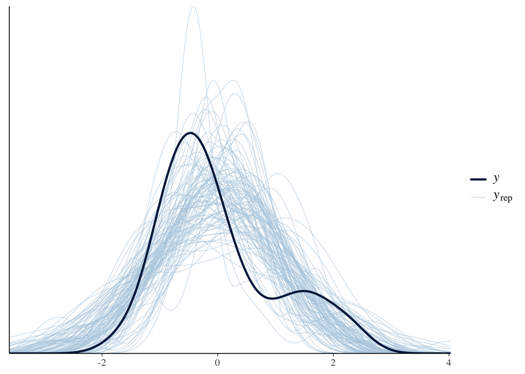

```r
mod1_predict <- posterior_predict(mod1, draws = 100)

library(bayesplot)
ppc_dens_overlay(y = dem_data$federal_unitry_1981_2010, yrep = mod1_predict)
```

Jeg vil si at vår modell passer godt til de predikerte datene. Hovedinnvendingen er kanskje at de predikerte dataene ikke fanger opp de to modusene i de observerte dataene, men ellers er likheten god og jeg aner ingen systematisk feil i den observerte fordelingen.

# 5 Oppgave 5

```r
dem_data_1_b <- data.frame(pop_in_thousands_2009 = 1e6)

bil_predict <- posterior_predict(mod1, newdata = dem_data_1_b)

p_bil_predict <- mean(bil_predict[,1] > 1)
```

Sannsynligheten for at et land med 1 milliard innbyggere scorer over 1 på føderasjonsskalaen til Lijphart er 0.62475. Dette viser til at store land, mest sannsynlig er føderasjoner; noe som stemmer overens med i alle fall min intuisjon.

# 6 Ekstra oppgaver

## 6.1 Oppgave 6

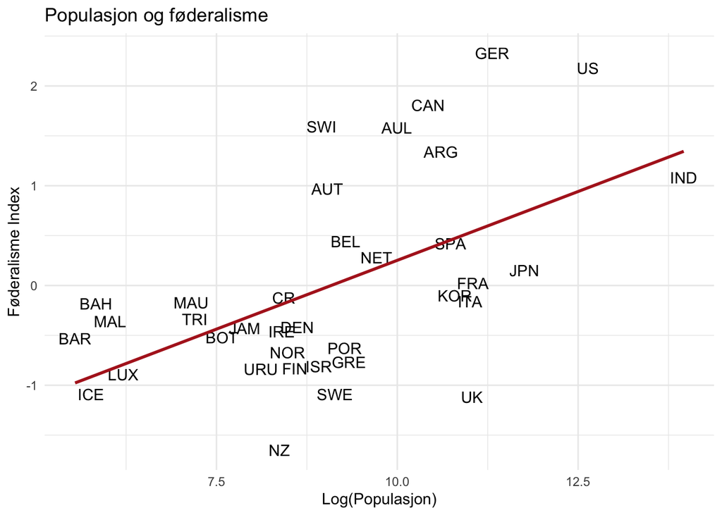

```r
scatter_country <- ggplot(data = dem_data, aes(x = log(pop_in_thousands_2009), y = federal_unitry_1981_2010, label = country)) +
  geom_text() +
  geom_smooth(method = "lm", formula = y ~ x, stat = "smooth", col = "firebrick", alpha = 0) +
    theme_minimal() +
  labs(
    title = "Populasjon og føderalisme",
    x = "Log(Populasjon)",
    y = "Føderalisme Index"
  )


scatter_country
```

## 6.2 Oppgave 7

### 6.2.1 Med egne prediksjoner, manuelt

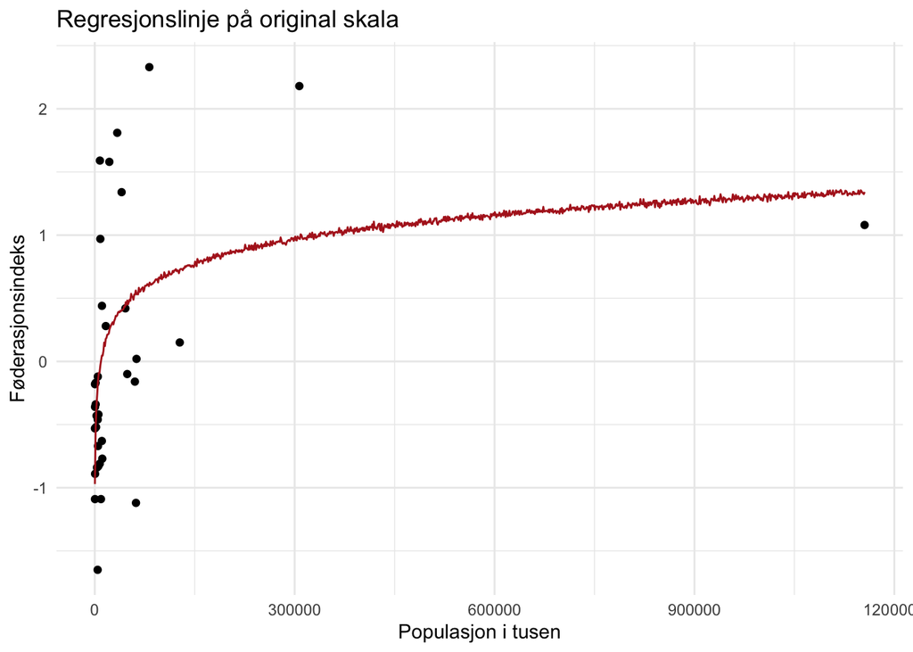

```r
x_seq <- data.frame(pop_in_thousands_2009 = seq(
  from = min(dem_data$pop_in_thousands_2009),
  to   = max(dem_data$pop_in_thousands_2009),
  length.out = 1000
))


y_pred <- posterior_predict(mod1, newdata = x_seq)

pred_log <- tibble(
  x_seq = log(x_seq$pop_in_thousands_2009),
  y_pred = colMeans(y_pred)
)

pred_exp <- pred_log |>
  mutate(x = exp(x_seq),
         y = y_pred)

exp_scatter <- ggplot(data = dem_data, aes(x = pop_in_thousands_2009, y = federal_unitry_1981_2010)) +
  geom_point() +
  geom_line(data = pred_exp, aes(x = x, y = y), stat = "identity", color = "firebrick") +
  theme_minimal() +
  labs(
    title = "Regresjonslinje på original skala",
    x = "Populasjon i tusen",
    y = "Føderasjonsindeks"
  )

exp_scatter
```

### 6.2.2 Med geom_smooth

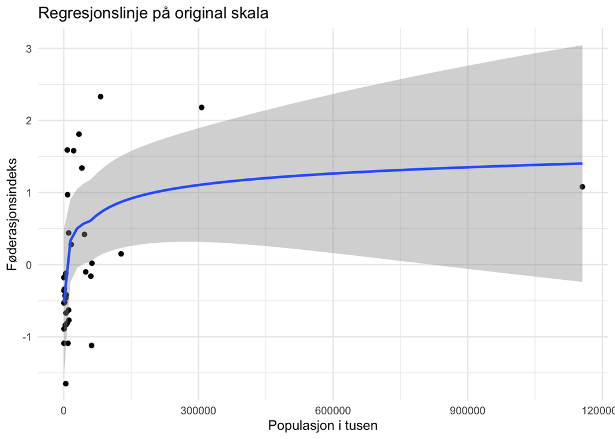

```r
exp_scatter_smooth <- ggplot(data = dem_data,
                             aes(x = pop_in_thousands_2009,
                                 y = federal_unitry_1981_2010)) +
  geom_point() +
  geom_smooth(formula = y ~ log(x)) +
  theme_minimal() +
  labs(
    title = "Regresjonslinje på original skala",
    x = "Populasjon i tusen",
    y = "Føderasjonsindeks"
  )

exp_scatter_smooth
```

## 6.3 Oppgave 8

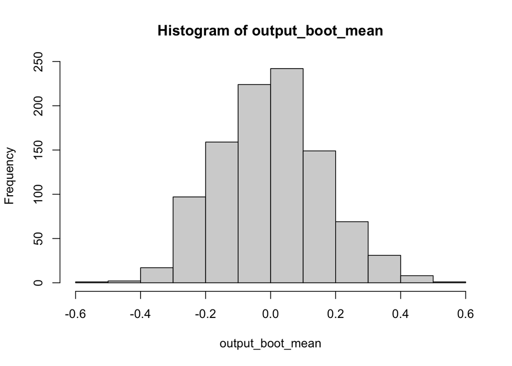

```r
boot_mean <- function(x) {
  n <- nrow(x)
  boot <- sample(1:n, replace = TRUE)
  fed_boot <- dem_data$federal_unitry_1981_2010[boot]
  mean_boot <- mean(fed_boot)
  return(mean_boot)
}

n_sims <- 1000
output_boot_mean <- replicate(n_sims, boot_mean(dem_data))

hist(output_boot_mean)
```

```r
sd(output_boot_mean)
```

```
[1] 0.1611081
```

```r
sd(dem_data$federal_unitry_1981_2010)/sqrt(length(dem_data$federal_unitry_1981_2010))
```

```
[1] 0.1665983
```

```r
t_value <- qt(0.975, length(dem_data$federal_unitry_1981_2010-1))

conf_top <- mean(output_boot_mean) + (sd(output_boot_mean)*t_value)
conf_bottom <- mean(output_boot_mean) - (sd(output_boot_mean)*t_value)
```

Konfidensintervallet til den bootstrappede fordelingen er gitt mellom 0.3276019 og -0.325883

## 6.4 Oppgave 9

```r
median(dem_data$federal_unitry_1981_2010)
```

```
[1] -0.26
```

```r
boot_median <- function(x) {
  n <- nrow(x)
  boot <- sample(1:n, replace = TRUE)
  fed_boot <- dem_data$federal_unitry_1981_2010[boot]
  median_boot <- median(fed_boot)
  return(median_boot)
}

output_boot_median <- replicate(n_sims, boot_median(dem_data))

all.equal(mean(output_boot_median), median(dem_data$federal_unitry_1981_2010))
```

```
[1] "Mean relative difference: 0.02503047"
```

```r
sd(output_boot_median)
```

```
[1] 0.1475545
```

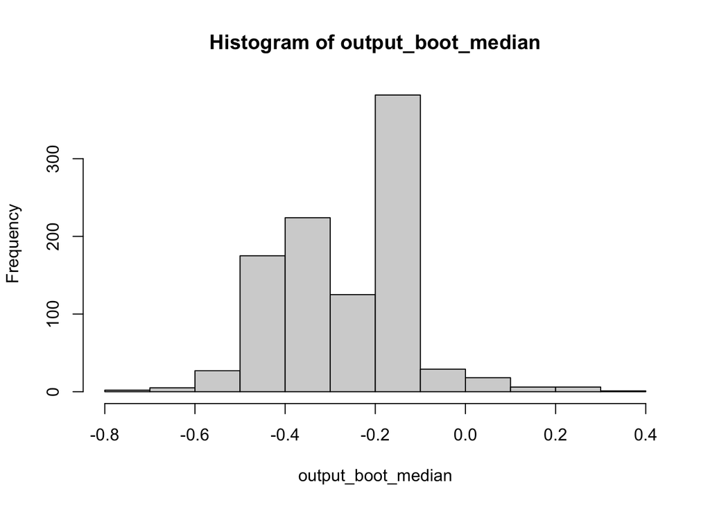

```r
hist(output_boot_median, binwidth = 0.1)
```

## 6.5 Oppgave 10

```r
rnd_values <- runif(2, min = -10, max = 10)
mean(rnd_values)
```

```
[1] 2.417778
```

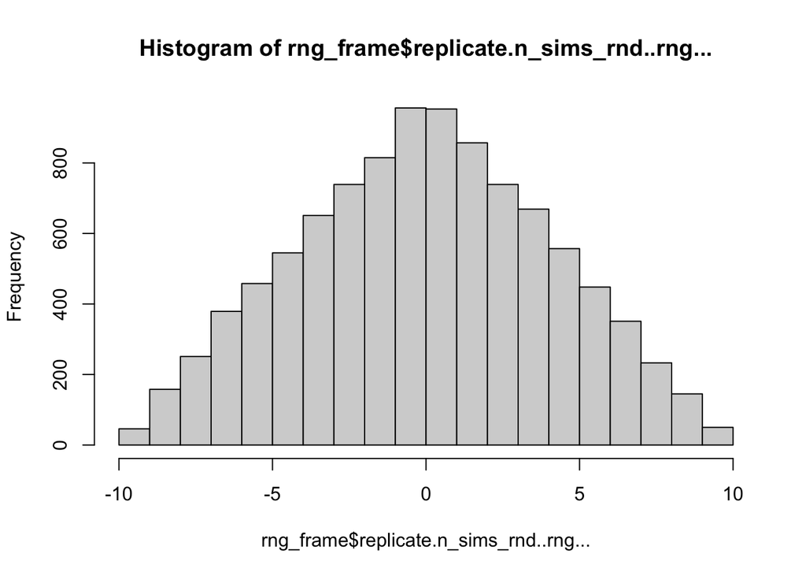

```r
n_sims_rnd <- 10000
rng <- function(){
  n <- 2
  min <- -10
  max <- 10
  rnd_func <- runif(n,min,max)
  return(mean(rnd_func))
}

rng_frame <- data.frame(replicate(n_sims_rnd, rng()))

hist(rng_frame$replicate.n_sims_rnd..rng...)
```

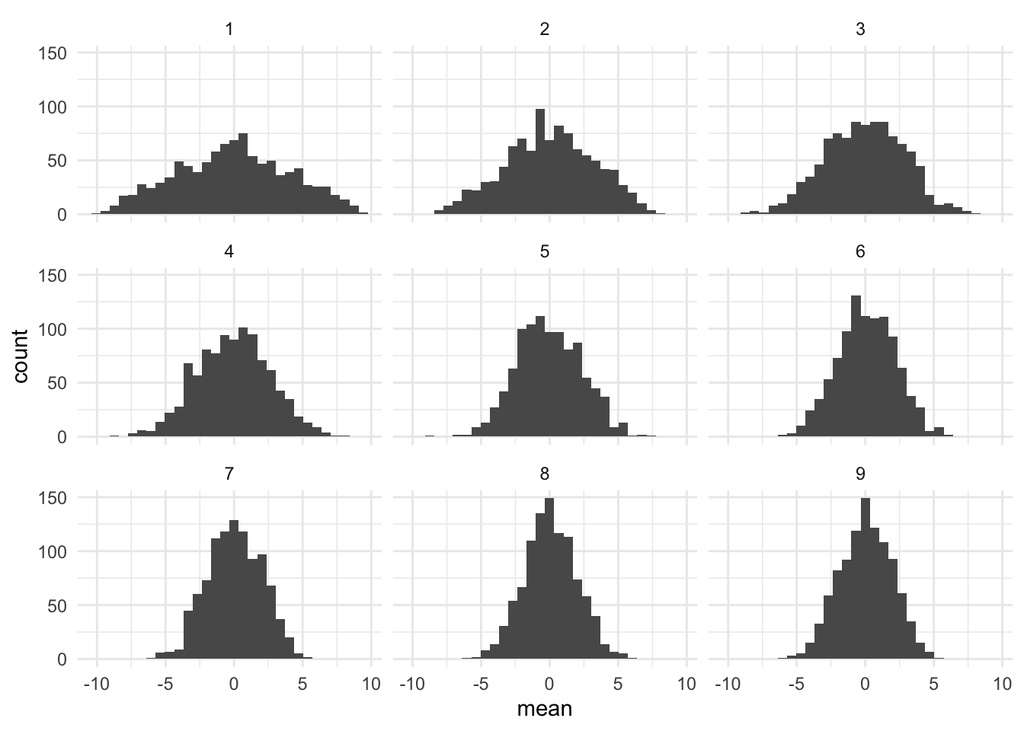

```r
n_var <- c(2, 3, 4, 5, 6, 7, 8, 9, 10)

rng_var <- function(n){
  min <- -10
  max <- 10
  rnd_func <- runif(n,min,max)
  return(mean(rnd_func))
}

rng_frame2 <- sapply(n_var, function(n) replicate(n_sims, rng_var(n))) |>
  as.data.frame()

rng_frame2_long <- rng_frame2 |>
  pivot_longer(cols = everything(),
               names_to = "n",
               values_to = "mean") |>
  mutate(n = str_remove(n, "V"))


plot_rng_facet <- ggplot(data = rng_frame2_long, aes(x=mean)) +
  geom_histogram() +
  facet_wrap(~n) +
  theme_minimal()

plot_rng_facet
```